# PROJECT 2: SUPERVISED LEARNING: FRAUD DETECTION

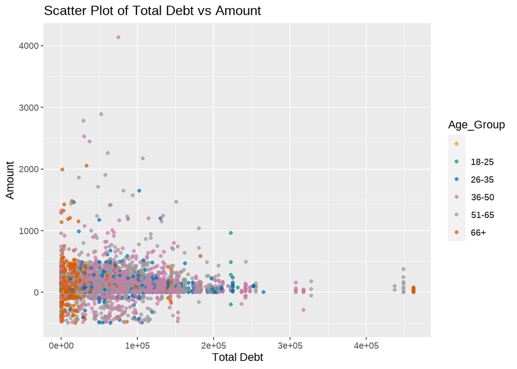

```r
# Scatter Plot for Total_Debt and Amount
ggplot(sampled_train_set_class, aes(x = Total_Debt, y = Amount, color = Age_Group)) +
  geom_point(alpha = 0.7) +
  labs(title = "Scatter Plot of Total Debt vs Amount", x = "Total Debt", y = "Amount")
```

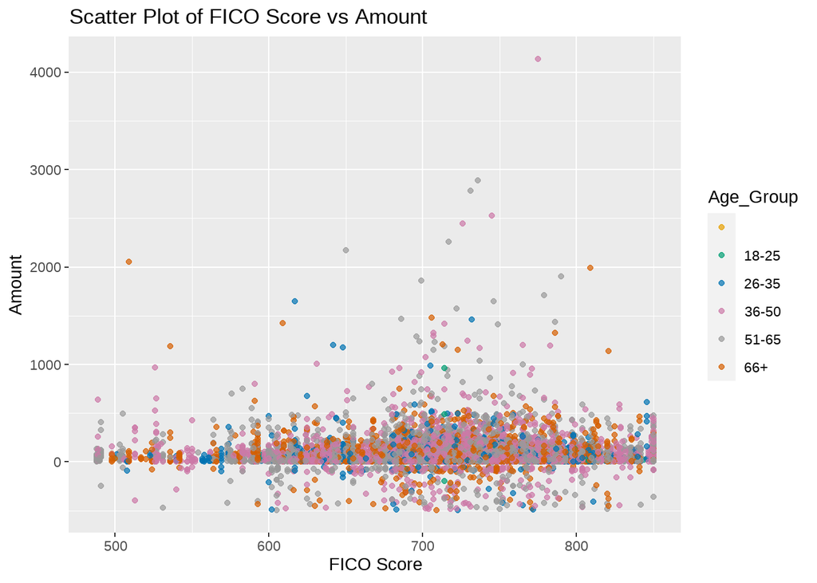

```r
# Scatter Plot for FICO_Score and Amount
ggplot(sampled_train_set_class, aes(x = FICO_Score, y = Amount, color =  Age_Group)) +
  geom_point(alpha = 0.7) +
  labs(title = "Scatter Plot of FICO Score vs Amount", x = "FICO Score", y = "Amount")
```

There is no a clear relationship

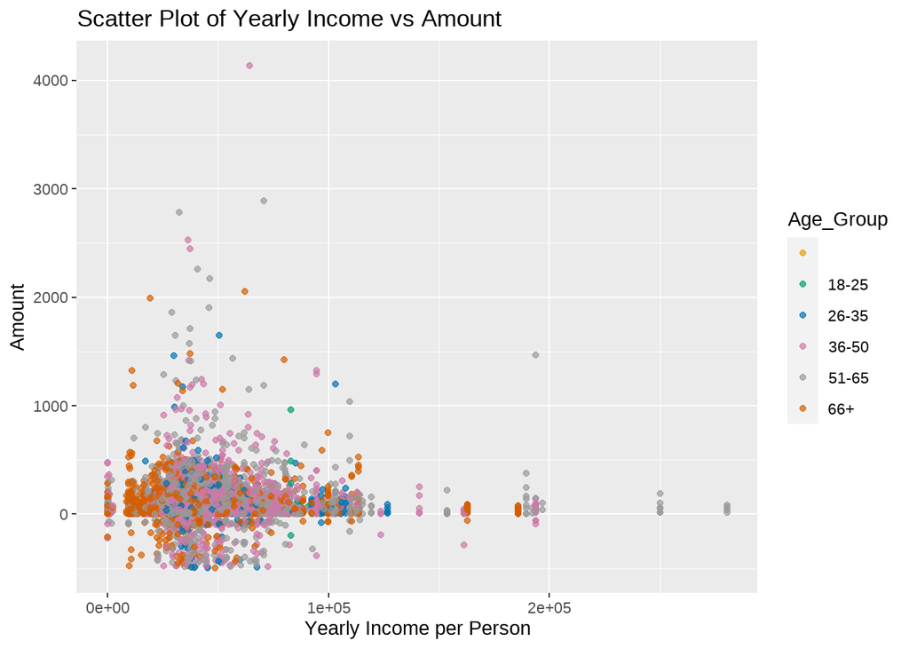

```r
# Scatter Plot for Yearly_Income_Person and Amount
ggplot(sampled_train_set_class, aes(x = Yearly_Income_Person, y = Amount, color =  Age_Group)) +
  geom_point(alpha = 0.7) +
  labs(title = "Scatter Plot of Yearly Income vs Amount", x = "Yearly Income per Person", y = "Amount")
```

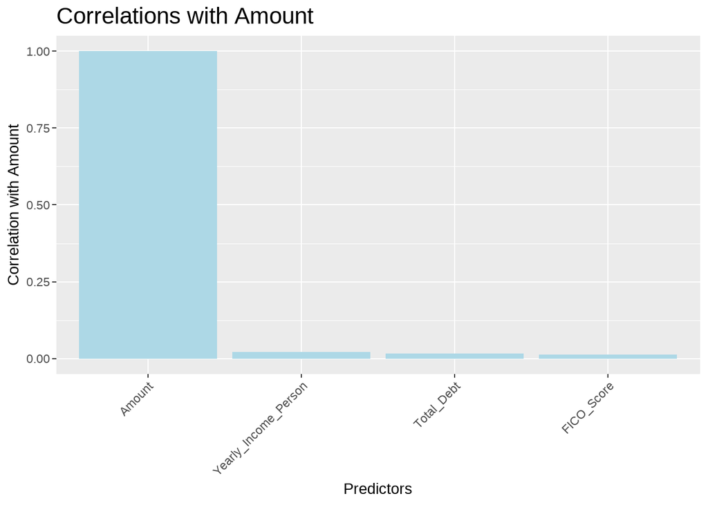

```r
# Assuming your dataframe is named sampled_train_set_class
corr_amount <- sort(cor(sampled_train_set_class[, c("Total_Debt", "FICO_Score", "Yearly_Income_Person", "Amount")])["Amount", ], decreasing = TRUE)
corr_data <- data.frame(variable = names(corr_amount), correlation = corr_amount)

library(ggplot2)

ggplot(corr_data, aes(x = variable, y = correlation)) +
  geom_bar(stat = "identity", fill = "lightblue") +
  scale_x_discrete(limits = corr_data$variable) +
  labs(x = "Predictors", y = "Correlation with Amount", title = "Correlations with Amount") +
  theme(plot.title = element_text(hjust = 0, size = rel(1.5)),
        axis.text.x = element_text(angle = 45, hjust = 1))
```

It can be seen that the numerical variables are not very related with the Amount.

## 5.3 Statistical Tools for Regression

### 5.3.1 Linear Regression

#### 5.3.1.1 Benchmark

The benchmark serves as our baseline, and in our case, it corresponds to predicting using the mean of transaction amounts. Our models consistently should exhibit higher accuracy compared to this benchmark.

```r
mean(sampled_train_set_class$Amount) # 76.64091
```

```
## [1] 76.64091
```

```r
benchFit <- lm(Amount ~ 1, data=sampled_train_set_class)
predictions <- predict(benchFit, newdata=sampled_test_set_class)
```

```r
RMSE = sqrt(mean((predictions - sampled_test_set_class$Amount)^2))
RMSE # 92.78234
```

```
## [1] 92.78234
```

#### 5.3.1.2 Simple linear regression

```r
linFit <- lm(Amount ~ Yearly_Income_Person, data=sampled_train_set_class)
summary(linFit)
```

```
##
## Call:
## lm(formula = Amount ~ Yearly_Income_Person, data = sampled_train_set_class)
##
## Residuals:
##    Min     1Q Median     3Q    Max
## -571.7  -64.4  -31.9   23.9 4053.6
##
## Coefficients:
##                       Estimate Std. Error t value Pr(>|t|)
## (Intercept)          6.944e+01  3.709e+00  18.723   <2e-16 ***
## Yearly_Income_Person 1.588e-04  7.288e-05   2.179   0.0293 *
## ---
## Signif. codes:  0 '***' 0.001 '**' 0.01 '*' 0.05 '.' 0.1 ' ' 1
##
## Residual standard error: 165.2 on 9670 degrees of freedom
## Multiple R-squared:  0.0004909,  Adjusted R-squared:  0.0003875
## F-statistic: 4.749 on 1 and 9670 DF,  p-value: 0.02933
```

The linear regression model aims to predict the Amount variable based on the Yearly_Income_Person predictor. The estimated intercept is 69.44, indicating the expected Amount when Yearly_Income_Person is zero. The coefficient for Yearly_Income_Person is 0.0001588, suggesting that, on average, a one-unit increase in Yearly_Income_Person is associated with an increase of 0.0001588 units in Amount. The p-value for the Yearly_Income_Person coefficient is 0.0293, which is below the conventional significance level of 0.05, suggesting that there is evidence to reject the null hypothesis that the coefficient is zero. However, the low multiple R-squared value (0.0004909) indicates that the model explains only a very small proportion of the variance in Amount. Therefore, while there is a statistically significant relationship between Yearly_Income_Person and Amount, the practical significance might be limited given the small effect size and low explanatory power of the model.

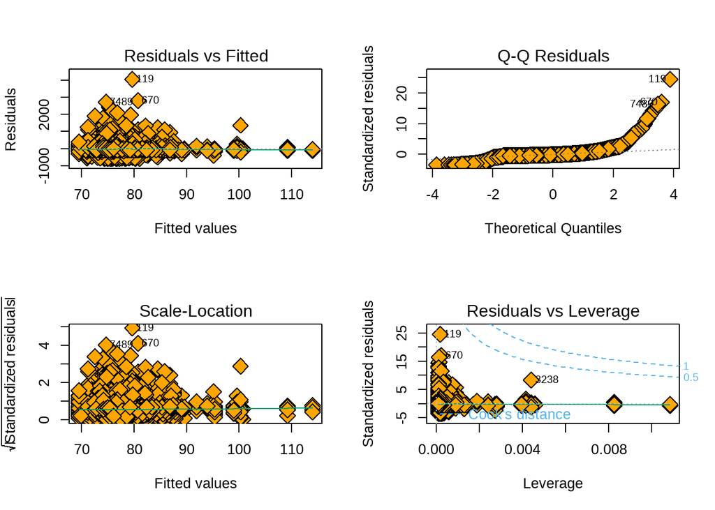

```r
par(mfrow=c(2,2))
plot(linFit, pch=23 ,bg='orange',cex=2)
```

```r
pr.simple = exp(predict(linFit, newdata=sampled_test_set_class))
cor(sampled_test_set_class$Amount, pr.simple)^2
```

```
## [1] 4.368747e-05
```

This is a really bad model.

#### 5.3.1.3 Multiple Linear Regression

```r
multi_linFit <- lm(Amount ~ Total_Debt + FICO_Score + Yearly_Income_Person, data = sampled_train_set_class)

# Print summary of the multiple regression model
summary(multi_linFit)
```

```
##
## Call:
## lm(formula = Amount ~ Total_Debt + FICO_Score + Yearly_Income_Person,
##     data = sampled_train_set_class)
##
## Residuals:
##    Min     1Q Median     3Q    Max
## -572.2  -64.4  -31.8   23.9 4051.3
##
## Coefficients:
##                       Estimate Std. Error t value Pr(>|t|)
## (Intercept)          4.162e+01  1.883e+01   2.210   0.0271 *
## Total_Debt           2.886e-05  3.832e-05   0.753   0.4514
## FICO_Score           3.848e-02  2.567e-02   1.499   0.1338
## Yearly_Income_Person 1.305e-04  8.466e-05   1.542   0.1231
## ---
## Signif. codes:  0 '***' 0.001 '**' 0.01 '*' 0.05 '.' 0.1 ' ' 1
##
## Residual standard error: 165.2 on 9668 degrees of freedom
## Multiple R-squared:  0.0007607,  Adjusted R-squared:  0.0004506
## F-statistic: 2.453 on 3 and 9668 DF,  p-value: 0.06133
```

In this multiple regression model, the intercept is 41.62, indicating the expected Amount when all predictor variables are zero. Among the predictor variables, only the intercept is statistically significant (p-value = 0.0271), suggesting a potential non-zero intercept. However, the coefficients for Total_Debt, FICO_Score, and Yearly_Income_Person are not statistically significant (p-values > 0.05). The small multiple R-squared value (0.0007607) indicates that the model explains a very small proportion of the variance in Amount. The F-statistic (2.453) and its associated p-value (0.06133) suggest that the overall model may not be statistically significant. Interpretation should be cautious, and further model refinement or consideration of additional variables may be needed.

```r
pr.multiple = exp(predict(multi_linFit, newdata=sampled_test_set_class))
cor(sampled_test_set_class$Amount, pr.multiple)^2
```

```
## [1] 0.0001530747
```

This low R-squared value suggests that the multiple regression model may not be effectively capturing the variability in the Amount variable in the test set.

#### 5.3.1.4 Cross Validation with Caret

```r
ctrl <- trainControl(method = "repeatedcv",
                     number = 5, repeats = 5, allowParallel = TRUE)
```

As we need to try lots of models, let’s save all predictos in the followinf dataframe

```r
test_results <- data.frame(Amount = sampled_test_set_class$Amount)
```

##### 5.3.1.4.1 Linear Regression

First, define our model

```r
model = Amount ~ Total_Debt + FICO_Score + Yearly_Income_Person
```

Then, we train our model

```r
lm_tune <- train(model, data = sampled_train_set_class,
                 method = "lm",
                 preProc=c('scale', 'center'),
                 trControl = ctrl)
lm_tune
```

```
## Linear Regression
##
## 9672 samples
##    3 predictor
##
## Pre-processing: scaled (3), centered (3)
## Resampling: Cross-Validated (5 fold, repeated 5 times)
## Summary of sample sizes: 7738, 7738, 7739, 7737, 7736, 7739, ...
## Resampling results:
##
##   RMSE      Rsquared      MAE
##   164.9308  0.0005890773  84.50019
##
## Tuning parameter 'intercept' was held constant at a value of TRUE
```

In summary, the linear regression model, after tuning and cross-validation, exhibits an RMSE of 164.9308, an R-squared value of 0.0005890773, and an MAE of 84.50019. While the model provides predictions, the low R-squared value indicates that the predictors may not be effectively explaining the variability in the response variable.

**Prediction**

```r
test_results$lm <- predict(lm_tune, sampled_test_set_class)
postResample(pred = test_results$lm,  obs = test_results$Amount)
```

```
##         RMSE     Rsquared          MAE
## 92.608041265  0.006105115 59.978977501
```

```
    RMSE     Rsquared          MAE
```

92.608041265 0.006105115 59.978977501

**Visualization**

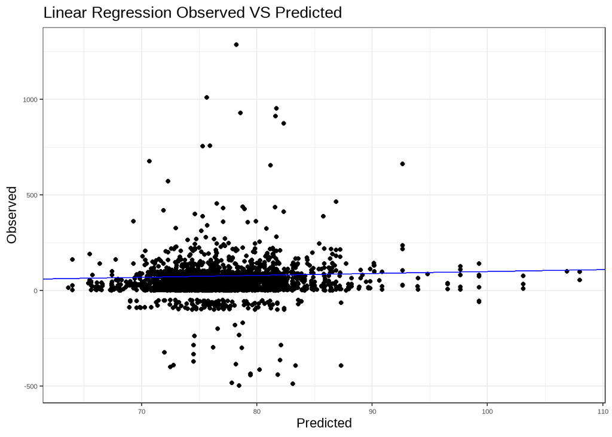

```r
ggplot(test_results, aes(x = lm, y = Amount)) +
  geom_point() +
  geom_abline(intercept = 0, slope = 1, colour = "blue") +
  labs(title = "Linear Regression Observed VS Predicted", x = "Predicted", y = "Observed") +
  theme_bw()
```

We can see that the model don’t look really linear

##### 5.3.1.4.2 Overfitted Linear Regression

First, define our model

```r
model2 = Amount ~ Total_Debt + FICO_Score + Yearly_Income_Person + Credit_Limit + Num_Credit_Cards + Current_Age + Latitude + Longitude
```

Then, we train our model

```r
lm_tune2 <- train(model2, data = sampled_train_set_class,
                 method = "lm",
                 preProc=c('scale', 'center'),
                 trControl = ctrl)
lm_tune2
```

```
## Linear Regression
##
## 9672 samples
##    8 predictor
##
## Pre-processing: scaled (8), centered (8)
## Resampling: Cross-Validated (5 fold, repeated 5 times)
## Summary of sample sizes: 7736, 7740, 7737, 7737, 7738, 7737, ...
## Resampling results:
##
##   RMSE      Rsquared      MAE
##   164.6602  0.0006802417  84.44921
##
## Tuning parameter 'intercept' was held constant at a value of TRUE
```

**Prediction**

```r
test_results$lm2 <- predict(lm_tune2, sampled_test_set_class)
postResample(pred = test_results$lm2,  obs = test_results$Amount)
```

```
##         RMSE     Rsquared          MAE
## 92.542403295  0.002741965 59.770585144
```

```
    RMSE     Rsquared          MAE
```

92.542403295 0.002741965 59.770585144

**Visualization**

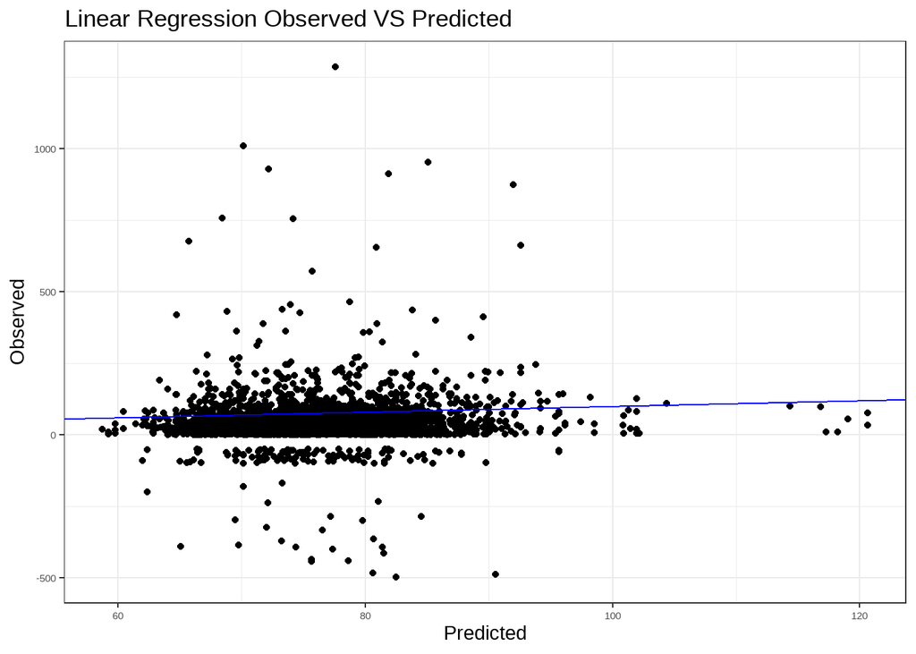

```r
ggplot(test_results, aes(x = lm2, y = Amount)) +
  geom_point() +
  geom_abline(intercept = 0, slope = 1, colour = "blue") +
  labs(title = "Linear Regression Observed VS Predicted", x = "Predicted", y = "Observed") +
  theme_bw()
```

Actually pretty similar than the simple regression.

### 5.3.2 Variable Selection Techniques

#### 5.3.2.1 Forward regression

The forward regression process incrementally builds the model by selecting predictors one at a time based on their individual contribution. It’s important to note that forward regression may not explore all possible combinations of predictors, and the final model may not be the best overall model. It is a greedy algorithm that makes locally optimal choices at each step.

```r
for_tune <- train(model2, data = sampled_train_set_class,
                  method = "leapForward",
                  preProc=c('scale', 'center'),
                  tuneGrid = expand.grid(nvmax = 2:8),
                  trControl = ctrl)

for_tune
```

```
## Linear Regression with Forward Selection
##
## 9672 samples
##    8 predictor
##
## Pre-processing: scaled (8), centered (8)
## Resampling: Cross-Validated (5 fold, repeated 5 times)
## Summary of sample sizes: 7739, 7738, 7737, 7736, 7738, 7737, ...
## Resampling results across tuning parameters:
##
##   nvmax  RMSE      Rsquared      MAE
##   2      164.5899  0.0010158155  84.42709
##   3      164.6483  0.0006162420  84.46872
##   4      164.6597  0.0006230957  84.46689
##   5      164.6525  0.0006499417  84.45545
##   6      164.6490  0.0006689309  84.45253
##   7      164.6563  0.0006235875  84.45562
##   8      164.6553  0.0006259610  84.45368
##
## RMSE was used to select the optimal model using the smallest value.
## The final value used for the model was nvmax = 2.
```

The train function with forward variable selection (leapForward method) has been performed on model2 with different values of nvmax. The results indicate the performance metrics (RMSE, Rsquared, MAE) for each value of nvmax. The selected model has nvmax = 2 based on the smallest RMSE value.

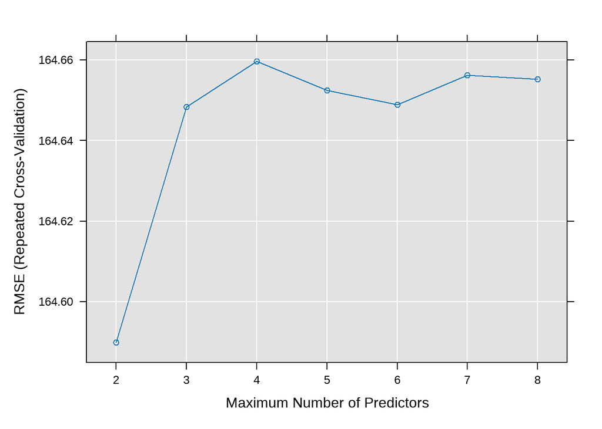

```r
plot(for_tune)
```

Now we need to select those best variables

```r
coef(for_tune$finalModel, for_tune$bestTune$nvmax)
```

```
##          (Intercept) Yearly_Income_Person     Num_Credit_Cards
##            76.640910             3.842341             4.474577
```

The coefficients for Yearly_Income_Person and Num_Credit_Cards indicate the estimated change in the response variable for a one-unit increase in each of these predictors, assuming all other variables are held constant

**Prediction**

```r
test_results$frw <- predict(for_tune, sampled_test_set_class)
postResample(pred = test_results$frw,  obs = test_results$Amount)
```

```
##         RMSE     Rsquared          MAE
## 92.530832150  0.002415664 59.769348206
```

```r
#        RMSE     Rsquared          MAE
# 92.530832150  0.002415664 59.769348206
```

**Visualization**

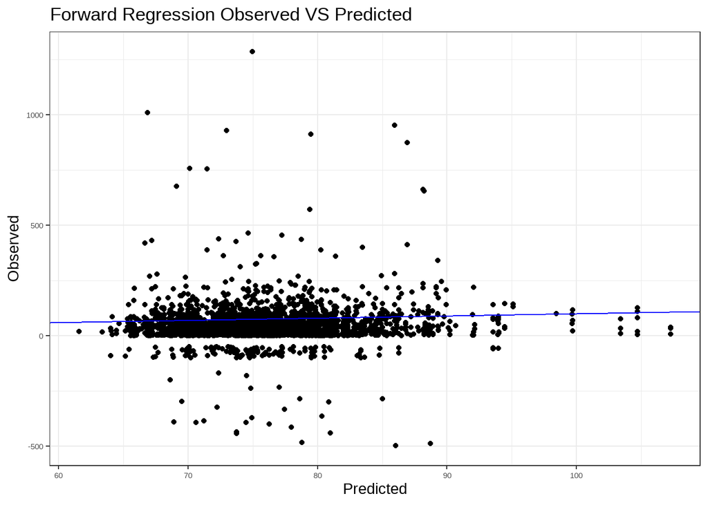

```r
ggplot(test_results, aes(x = frw, y = Amount)) +
  geom_point() +
  geom_abline(intercept = 0, slope = 1, colour = "blue") +
  labs(title = "Forward Regression Observed VS Predicted", x = "Predicted", y = "Observed") +
  theme_bw()
```

Very similar to lm

```r
back_tune  <- train(model2, data = sampled_train_set_class,
                  method = "leapBackward",
                  preProc=c('scale', 'center'),
                  tuneGrid = expand.grid(nvmax = 2:8),
                  trControl = ctrl)

back_tune
```

```
## Linear Regression with Backwards Selection
##
## 9672 samples
##    8 predictor
##
## Pre-processing: scaled (8), centered (8)
## Resampling: Cross-Validated (5 fold, repeated 5 times)
## Summary of sample sizes: 7738, 7738, 7738, 7737, 7737, 7738, ...
## Resampling results across tuning parameters:
##
##   nvmax  RMSE      Rsquared      MAE
##   2      164.5261  0.0008064521  84.45996
##   3      164.5573  0.0007143835  84.47250
##   4      164.5669  0.0007261807  84.47296
##   5      164.5634  0.0007875651  84.45945
##   6      164.5645  0.0008227789  84.46169
##   7      164.5629  0.0007943198  84.45628
##   8      164.5676  0.0007763660  84.45823
##
## RMSE was used to select the optimal model using the smallest value.
## The final value used for the model was nvmax = 2.
```

Again it selects nvmax = 2

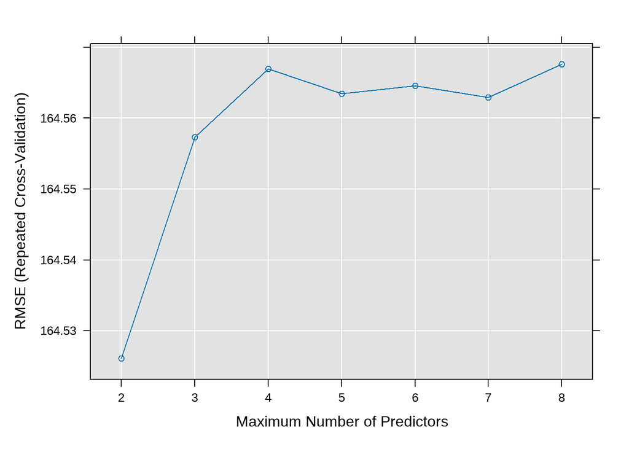

```r
plot(back_tune)
```

Now we need to select those best variables

```r
coef(back_tune$finalModel, back_tune$bestTune$nvmax)
```

```
##          (Intercept) Yearly_Income_Person     Num_Credit_Cards
##            76.640910             3.842341             4.474577
```

**Prediction**

```r
test_results$bw  <- predict(back_tune, sampled_test_set_class)
postResample(pred = test_results$bw ,  obs = test_results$Amount)
```

```
##         RMSE     Rsquared          MAE
## 92.530832150  0.002415664 59.769348206
```

```r
#        RMSE     Rsquared          MAE
#92.530832150  0.002415664 59.769348206
```

**Visualization**

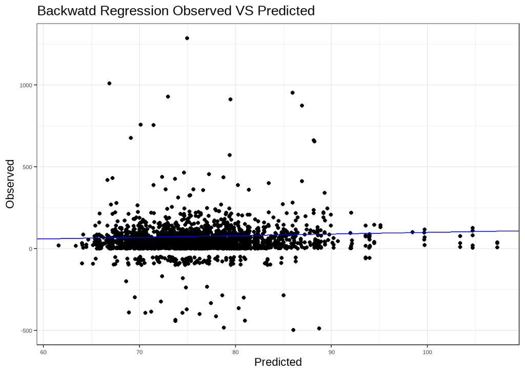

```r
ggplot(test_results, aes(x = bw, y = Amount)) +
  geom_point() +
  geom_abline(intercept = 0, slope = 1, colour = "blue") +
  labs(title = "Backwatd Regression Observed VS Predicted", x = "Predicted", y = "Observed") +
  theme_bw()
```

Very similar to lm

#### 5.3.2.3 Stepwise regression

```r
set.seed(123)
step_tune   <- train(model2, data = sampled_train_set_class,
                  method = "leapSeq",
                  preProc=c('scale', 'center'),
                  tuneGrid = expand.grid(nvmax = 2:8),
                  trControl = ctrl)

step_tune
```

```
## Linear Regression with Stepwise Selection
##
## 9672 samples
##    8 predictor
##
## Pre-processing: scaled (8), centered (8)
## Resampling: Cross-Validated (5 fold, repeated 5 times)
## Summary of sample sizes: 7737, 7738, 7737, 7738, 7738, 7738, ...
## Resampling results across tuning parameters:
##
##   nvmax  RMSE      Rsquared      MAE
##   2      164.6764  0.0012111690  84.48114
##   3      164.6903  0.0009182049  84.47449
##   4      164.7418  0.0008114145  84.50430
##   5      164.7277  0.0009074602  84.48904
##   6      164.7247  0.0009143121  84.48349
##   7      164.7298  0.0009177065  84.48695
##   8      164.7437  0.0008503171  84.49594
##
## RMSE was used to select the optimal model using the smallest value.
## The final value used for the model was nvmax = 2.
```

Again it selects nvmax = 2

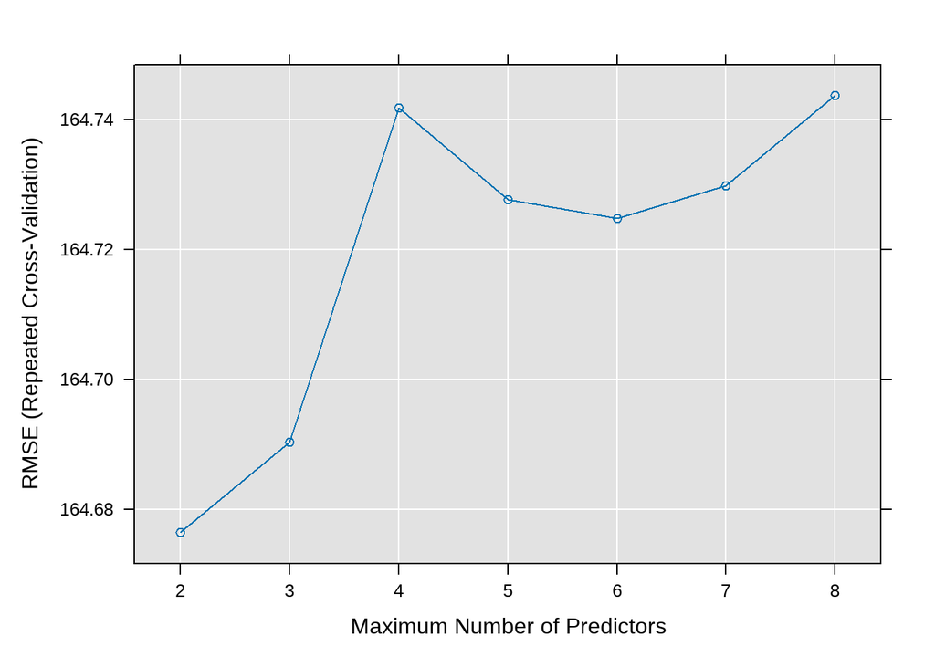

```r
plot(step_tune )
```

Now we need to select those best variables

```r
coef(step_tune $finalModel, step_tune $bestTune$nvmax)
```

```
##          (Intercept) Yearly_Income_Person     Num_Credit_Cards
##            76.640910             3.842341             4.474577
```

**Prediction**

```r
test_results$seq  <- predict(step_tune , sampled_test_set_class)
postResample(pred = test_results$seq ,  obs = test_results$Amount)
```

```
##         RMSE     Rsquared          MAE
## 92.530832150  0.002415664 59.769348206
```

```r
#        RMSE     Rsquared          MAE
#92.530832150  0.002415664 59.769348206
```

**Visualization**

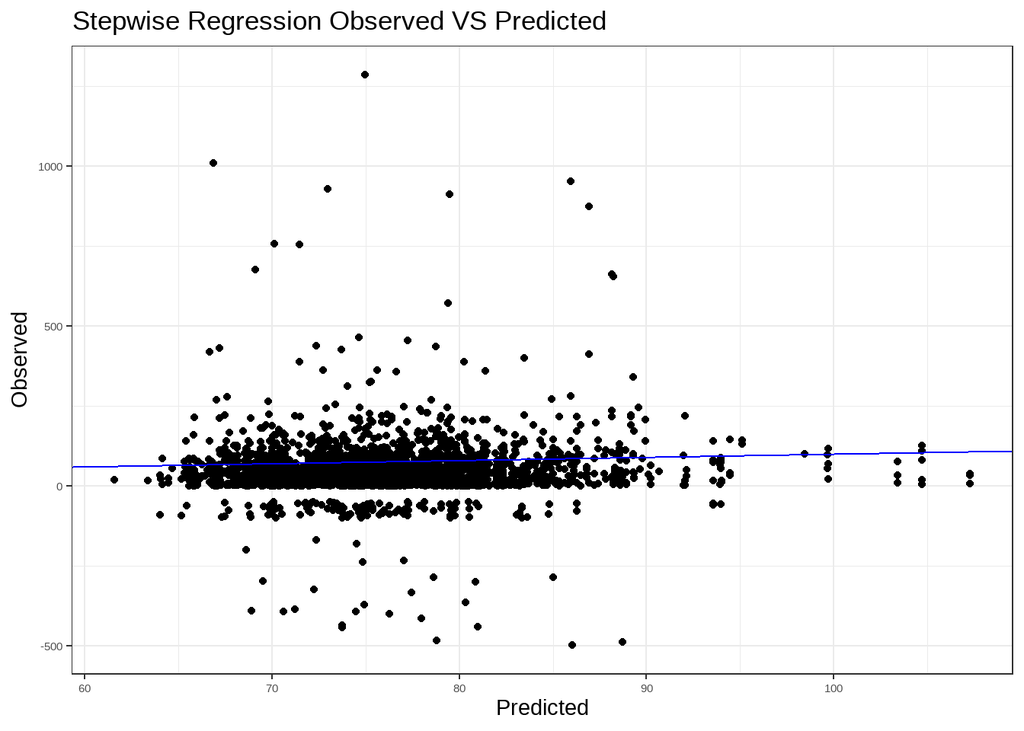

```r
ggplot(test_results, aes(x = seq, y = Amount)) +
  geom_point() +
  geom_abline(intercept = 0, slope = 1, colour = "blue") +
  labs(title = "Stepwise Regression Observed VS Predicted", x = "Predicted", y = "Observed") +
  theme_bw()
```

Very similar to lm

### 5.3.3 Regularization Methods

#### 5.3.3.1 Ridge regression

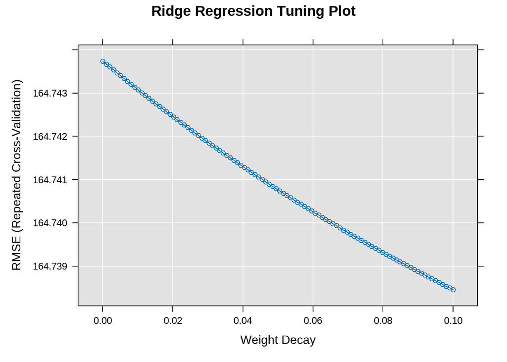

```r
# the grid for lambda
ridge_grid <- expand.grid(lambda = seq(0, .1, length = 100))

# train
set.seed(123)
ridge_tune <- train(model2, data = sampled_train_set_class,
                    method='ridge',
                    preProc=c('scale','center'),
                    tuneGrid = ridge_grid,
                    trControl=ctrl)
plot(ridge_tune, main = "Ridge Regression Tuning Plot")
```

```r
# the best tune
ridge_tune$bestTune
```

```
##     lambda
## 100    0.1
```

In the plot, it is noteworthy that the decrease in RMSE exhibits a pattern reminiscent of a negatively sloped linear relationship as the regularization parameter, lambda, increases. This observation suggests a systematic and almost linear reduction in RMSE, reinforcing the correlation between the strength of regularization and the model’s predictive performance.

```r
test_results$ridge <- predict(ridge_tune, sampled_test_set_class)

postResample(pred = test_results$ridge,  obs = test_results$Amount)
```

```
##         RMSE     Rsquared          MAE
## 92.539994403  0.002789309 59.762595976
```

```r
#        RMSE     Rsquared          MAE
#92.539994403  0.002789309 59.762595976
```

The performance metrics for the ridge regression model on our dataset reveal notable results. The Root Mean Square Error (RMSE) is calculated at 92.54, indicating the average magnitude of prediction errors. The R-squared value of 0.0028 suggests a limited proportion of variance in the response variable is explained by the model. Lastly, the Mean Absolute Error (MAE) is determined as 59.76, providing an average of the absolute differences between predicted and observed values. While the RMSE and R-squared values suggest room for improvement in predictive accuracy, the MAE underscores the model’s ability to minimize the impact of outliers. These insights contribute to a comprehensive understanding of the ridge regression model’s performance, guiding potential refinements to enhance its predictive capabilities.